# Частотный анализ исторических шифров.

## Шифр Атбаш

Построение частотный гистограммы `шифра Атбаша`

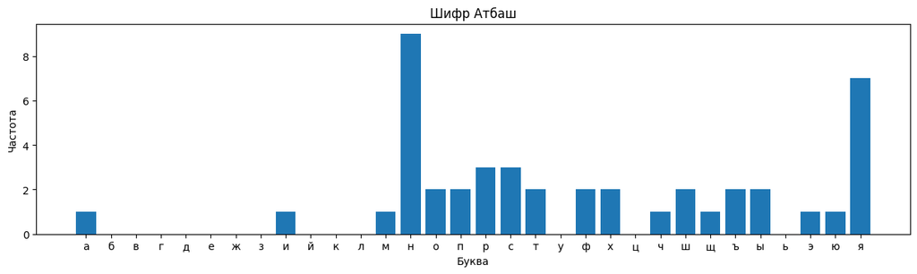

```python
import matplotlib.pyplot as plt
import string
from collections import Counter
import itertools

RUSSIAN_ALP="абвгдежзийклмнопрстуфхцчшщъыьэюя"

def create_histogram(text: str, x: int, lab: str, alp=RUSSIAN_ALP, count_col=2) -> None:
    if ' ' in text:
        alphabet = list(alp.split())
        counter = Counter(text.lower().split())
    else:
        alphabet = list(alp)
        counter = Counter(text.lower())
    frequencies = [counter[letter] for letter in alphabet]
    plt.figure(figsize=(15,8))
    plt.subplot(count_col, 1, x)
    plt.bar(alphabet, frequencies)
    plt.xlabel('Буква')
    plt.ylabel('Частота')
    plt.title(lab)
    plt.show()

create_histogram("ТотЗПТктоложитсянадвастулаЗПТпадаетнаребраТЧК", 1, "Открытый текст")

create_histogram("нсншрнхнсфсщчноатяыэяонмфяшрнряыяънтяпъюпяних", 2, "Шифр Атбаш")
```

Размытия статистических характеристик в данном шифре не происходит, т.к. буквы алфавита только лишь меняются ролями. В итоге использования данного шифра получаем зеркальное отражение статистических характеристик в виду особенности алгоритма замены.

## Квадрат Полибия

Построение частотный гистограммы `шифра Полибия`

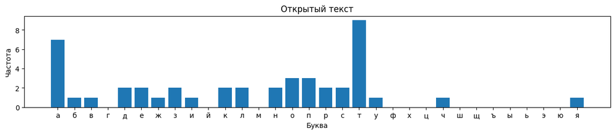

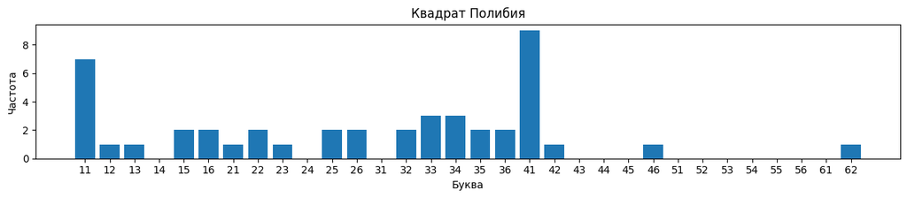

```python
create_histogram("ТотЗПТктоложитсянадвастулаЗПТпадаетнаребраТЧК", 1, "Открытый текст", RUSSIAN_ALP, 3)

create_histogram("41 33 41 22 34 41 25 41 33 26 33 21 23 41 36 62 32 11 15 13 11 36 41 42 26 11 22 34 41 34 11 15 11 16 41 32 11 35 16 12 35 11 41 46 25", 3, "Квадрат Полибия", "11 12 13 14 15 16 21 22 23 24 25 26 31 32 33 34 35 36 41 42 43 44 45 46 51 52 53 54 55 56 61 62", 3)
```

Если рассматривать биграммы (двузначные числа), то каждой букве открытого текста соответствует биграмма алфавита шифр обозначений,поэтому, проанализировав их, мы получили, что статистическое распределение не изменилось.

## Шифр Цезаря

Построение частотный гистограммы `Цезаря`

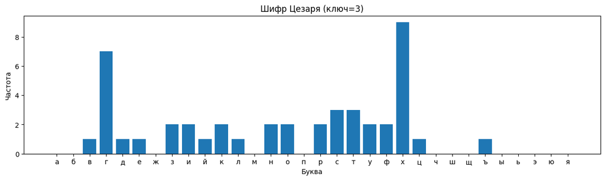

```python
create_histogram("ТотЗПТктоложитсянадвастулаЗПТпадаетнаребраТЧК", 1, "Открытый текст")

create_histogram("хсхктхнхсосйлхфвргзегфхцогктхтгзгихргуидугхън", 2, "Шифр Цезаря (ключ=3)")
```

Размытия статистических характеристик в данном шифре не происходит, т.к. буквы алфавита только лишь меняются ролями, а именно сдвигаются на 3 позиции правее. В итоге использования данного шифра-замены получаем статистические характеристики, сдвинутые на три позиции правее

## Шифр Тритемия

Построение частотный гистограммы `Тритемея`

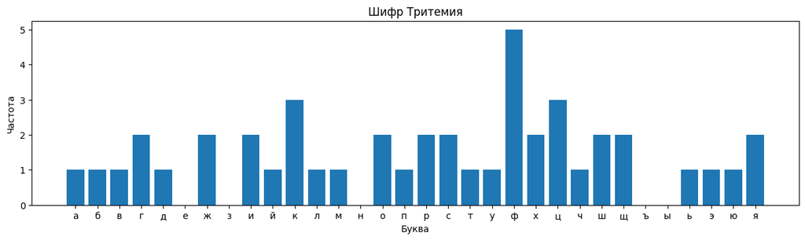

```python
create_histogram("ТотЗПТктоложитсянадвастулаЗПТпадаетнаребраТЧК", 1, "Открытый текст")

create_histogram("тпфкучрщцфшсфяяоэсцхфжикгщбкомюгажфрдхлишйьвц", 2, "Шифр Тритемия")
```

Ввиду того, что данный шифр-замены является полиалфавитным, его статистические характеристики «размываются». Криптостойкость данного шифра выше предыдущих, так как график более "ровный".

## Шифр Белазо

Построение частотный гистограммы `Белазо`

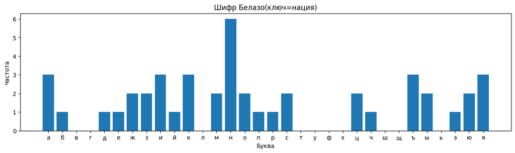

```python
create_histogram("ТотЗПТктоложитсянадвастулаЗПТпадаетнаребраТЧК", 1, "Открытый текст")

create_histogram("яоипюякзцкыжюърмнцмбнсиыкнзеъондчнсъажнаэаияй", 2, "Шифр Белазо(ключ=нация)")
```

Этот шифр-замены также является полиалфавитным. Его статистические характеристики «размываются», что увеличивает его криптостойкость.

## Шифр Виженера

Построение частотный гистограммы `Виженера`

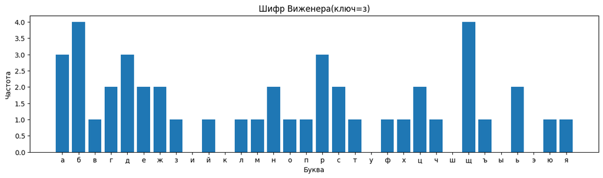

```python
create_histogram("ТотЗПТктоложитсянадвастулаЗПТпадаетнаребраТЧК", 1, "Открытый текст")

create_histogram("щаащцбььащщфоъгрмнджвсгеюлзцббпддечянрхжсртйб", 2, "Шифр Виженера(ключ=з)")
```

Ввиду того, что данный шифр-замены является полиалфавитным, его статистические характеристики «размываются». Визуально данный шифр наиболее хорошо это делает для нашего открытого текста, что обеспечит хорошую криптостойкость

## Решетка Кардано

Построение частотный гистограммы `Решетка Кардано`

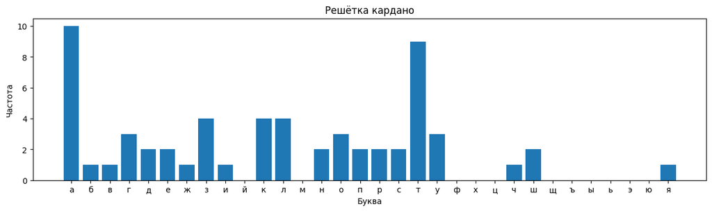

```python
create_histogram("ТотЗПТктоложитсянадвастулаЗПТпадаетнаребраТЧК", 1, "Открытый текст")

create_histogram("атздаагеялоунатдзгтватншскакттрауоезллбагоралтушачзкжптитпкс", 2, "Решётка кардано")
```

решетка Кардано является шифром маршрутной перестановки, она практически не размывает статистические характеристики (добавление избыточности в сообщении немного искажает их).

## Маршрутная перестановка

Построение частотный гистограммы `Маршрутная перестановка` Размерность 8 x 8

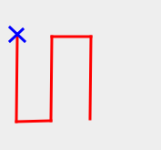

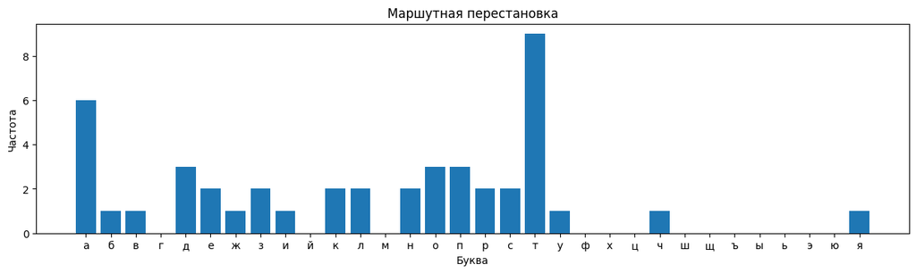

```python
create_histogram("ТотЗПТктоложитсянадвастулаЗПТпадаетнаребраТЧК", 1, "Открытый текст")

create_histogram("ттспроладеатодзтткстаетонларзжвпнчтяудбпиатак", 2, "Маршутная перестановка")
```

Данный шифр-перестановки «размывает» статистически характеристики только за счет добавления избыточности в сообщение. В нем практически нет «размытия» стат. характеристик.

## Вертикальная перестановка

Построение частотный гистограммы `Вертикальная перестановка`

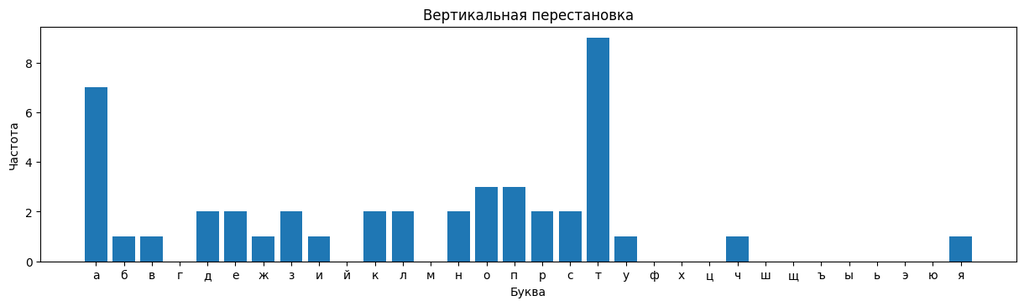

```python
create_histogram("ТотЗПТктоложитсянадвастулаЗПТпадаетнаребраТЧК", 1, "Открытый текст")

create_histogram("бдуяткстаерпсттпиатакчнпвжзтодзттаеаалотонлар", 2, "Вертикальная перестановка")
```

Данный шифр не размывает статистические характеристики вообще (в отличие от прошлых отстуствует даже добавление избыточности сообщения)

## Матричный шифр

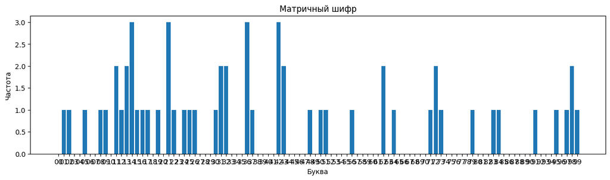

```python
create_histogram("ТотЗПТктоложитсянадвастулаЗПТпадаетнаребраТЧК", 1, "Открытый текст")

alp = str(' '.join(((''.join(x) for x in itertools.product("0123456789", repeat=2)))))

create_histogram("14 21 72 25 21 36 97 19 51 42 12 02 36 99 11 11 98 14 91 09 22 79 62 43 30 31 43 24 21 64 17 42 83 32 84 73 15 01 56 26 72 08 36 13 48 42 05 95 37 14 98 13 71 50 16 31 62 32 5", 2, "Матричный шифр", alp)
```

Матричный шифр хорошо размывает статистические характеристики открытого текста, так как является полиграммным.

## Шифр Плейфера

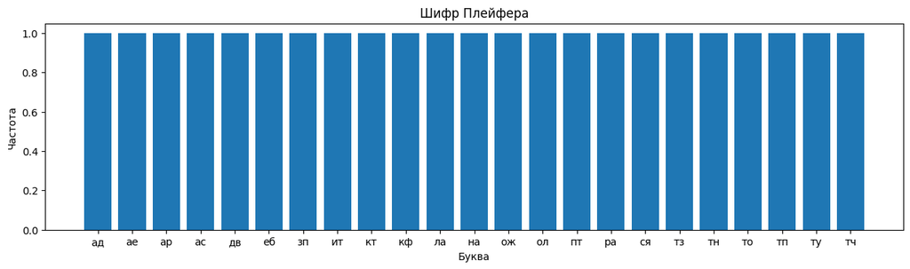

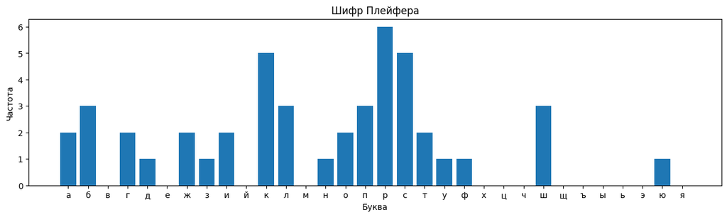

```python
create_histogram("ТотЗПТктоложитсянадвастулаЗПТпадаетнаребраТЧК", 1, "Открытый текст")

alp = itertools.product(RUSSIAN_ALP, repeat=2)
tmp = []
for i in alp:
    tmp.append(''.join(i))
en_message = "то тз пт кт ол ож ит ся на дв ас ту ла зп тп ад ае тн ар еб ра тч кф"

alp = list(filter(lambda x: x in en_message, tmp))
alp = ' '.join(alp)

create_histogram("то тз пт кт ол ож ит ся на дв ас ту ла зп тп ад ае тн ар еб ра тч кф", 2, "Шифр Плейфера", alp)
create_histogram("пбсисклкапжптштюарнздлкшфгжсксрбргкброирорсшлу", 2, "Шифр Плейфера")
```

Шифр Плейфера является шифром биграммной замены, поэтому если анализировать его биграммы на данном коротком открытом тексте, гистограмма асболютно ровная Если анализовать его по одному символу, то шифр размывает статистические характеристики, но присутствуют "пики"

## Одноразовый блокнот Шеннона

ГЕНЕРАТОР ГАММЫ

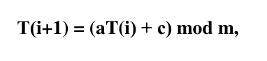

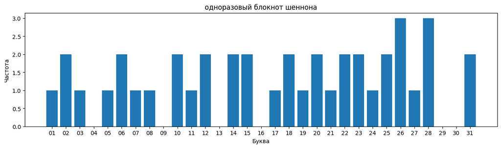

```python
create_histogram("ТотЗПТктоложитсянадвастулаЗПТпадаетнаребраТЧК", 1, "Открытый текст")

alp = list(map(str, list(range(1, 32))))
for i in range(len(alp)):
    while len(alp[i]) != 2:
        alp[i] = '0' + alp[i]
alp =  ' '.join(alp)
create_histogram("24 01 26 20 23 25 14 11 12 10 14 19 22 17 15 48 21 31 28 15 22 02 06 28 31 23 25 20 28 02 12 05 10 08 26 18 06 27 03 26 18 07 1", 2, "одноразовый блокнот шеннона", alp)
```

Одноразовый блокнот Шеннона обеспечивает хорошое размытие статистических характеристики открытого текста. На графике видны ровные части

## A5 / 2

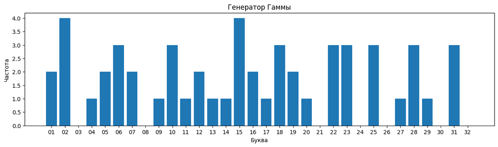

```python
create_histogram("ТотЗПТктоложитсянадвастулаЗПТпадаетнаребраТЧК", 1, "Открытый текст")

alp = list(map(str, list(range(1, 33))))
for i in range(len(alp)):
    while len(alp[i]) != 2:
        alp[i] = '0' + alp[i]
alp =  ' '.join(alp)
create_histogram("31 23 22 15 28 07 16 01 20 25 02 02 25 25 06 27 18 16 29 22 23 15 10 07 04 31 09 12 18 11 00 06 23 05 17 22 18 10 10 02 13 05 12 28 19 19 06 28 15 31 14 02 15 01", 2, "Генератор Гаммы", alp)
```

Блокнот Шеннона на генераторе гаммы A5/2 также показывает хорошое размытие стат характеристик и наличие ровных моментов.

## Шифр RSA

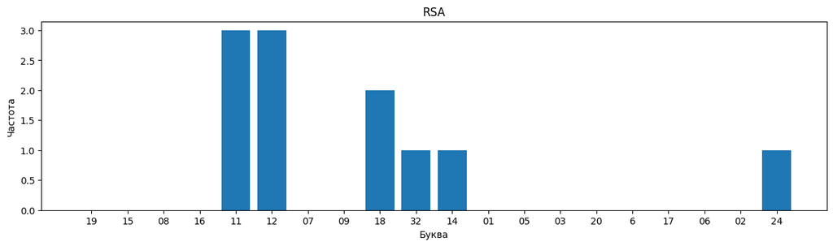

```python
create_histogram("ТотЗПТктоложитсянадвастулаЗПТпадаетнаребраТЧК", 1, "Открытый текст")

alp = str(' '.join(((''.join(x) for x in itertools.product("0123456789", repeat=3)))))
alp = " ".join(list(filter(lambda x: x != ' ' and int(x) < 222, alp.split())))


# ДОЛЖНА БЫТЬ 1 В 1 КАК В ОТКРЫТОМ ТЕКСТЕ

create_histogram("28 92 81 74 28 11 28 91 29 13 32 82 43 25 12 62 71 24 28 14 12 11 74 84 12 61 18 28 51 29 18 82 71 28 30 11", 2, "RSA", "19 15 19 08 16 19 11 19 15 12 15 07 09 19 18 32 14 01 05 03 01 18 19 20 12 01 08 16 19 16 01 05 01 6 19 14 01 17 06 02 17 01 19 24 11")
```

## Шифр ElGamal

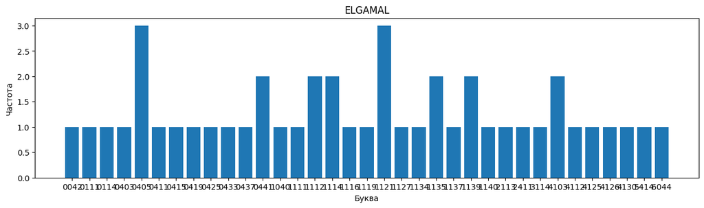

```python
create_histogram("ТотЗПТктоложитсянадвастулаЗПТпадаетнаребраТЧК", 1, "Открытый текст")
en_message = "4103 1114 0405 1139 1135 0405 1116 1112 1114 0419 4125 4126 0425 1112 1134 1127 0415 1121 0433 0437 1121 4130 0405 0403 1137 1121 1139 1135 4103 0411 0441 1119 0441 1140 0111 2113 6044 1111 3114 0114 2411 4112 1040 5414 0042 1"
alp = list(map(str, list(range(1, 10000))))
for i in range(len(alp)):
    while len(alp[i]) != 4:
        alp[i] = '0' + alp[i]
alp = ' '.join(list(filter(lambda x: x in en_message, alp)))

create_histogram(en_message, 2, "ELGAMAL", alp)
```

Шифр ElGamal показывает наилучшее размытие статистических характеристик. График практически ровный.

# Вывод

По моему мнению, судя по гистограмному анализу, наилучшим шифром для данного открытого текста является ассиметричный шифр ElGamal. Он наиболее сильно размывает статистические характеристики открытого текста и тем самым повышает его криптостойкость.